# Stabel_Sintia_HW2_V2

IST 652 – Scripting for Data Analysis Student: Sintia Stabel

## Super Bowl 2023 Tweeter Word Cloud and Sentiment Analysis

The Super Bowl is the championship game of the National Football League (NFL), which is the top professional football league in the United States. The Super Bowl has become an important cultural event in the United States, with 70 to 105 thousand people attending the event, and an average of 100 million viewers watching the game’s broadcast. The game is also known for its high-profile commercials which are broadcasted for the first time during the game and have become a major feature of the event. In the Super Bowl 2023, the teams Philadelphia Eagles and The Kansas City Chiefs faced off during what became the second most-watched program in American television history.

Given its immense popularity, the Super Bowl 2023 is a great subject for social media analysis using tools such as word cloud and sentiment analysis. Tweeter is a social media platform that allows people to share their views on various topics in the form of short messages. The messages are limited to 280 characters or less and the users can share “tweets” publicly or specific groups of followers. According to the Sports Business Journal, during the game, 603,000 tweets mentioning the Super Bowl were posted. Following is an exploration of 2 data samples containing 2000 tweets each, using a graphical representation called word cloud, and a machine learning model called Sentiment Analysis to determine if the overall sentiment, would have been a good predictor for who the Super Bowl winner was. To accomplish this, the answer to the following questions were set as target for the analysis:

1 – Can the overall word frequency and tweets sentiment correctly predict the Super Bowl’s winner?

2 – Is the choice of query words relevant for the accuracy of the results?

### About the data:

The SNS platform was used to scrape/collect 4000 samples of public tweets on the day of the Super Bowl 2023. The first 2000 tweets were collected using the query “Philadelphia Eagles”, and the second with the words “super bowl 2023”.

The tweets were saved in collections inside MongoDB databases. The collections were then saved as data frames to facilitate transformation and analytics. Preliminary data exploration showed that the “eaglesdb” and the “superdb” data sets, did not require any special transformations for the sentiment analysis purposes, as it would focus specifically on the “content” portion of the data sets. The only transformation performed was the removal of “stop words” prior to running the word cloud analysis.

#### Creating the "Philadelphia Eagles" tweeter collection

```python
# This program scrapes 2000 tweets from the Tweeter database using snscrape platform.
# The tweets are publically available and start and end on the day of the game 02-12-2023.
# A new mongoDB database was created: "eaglesdb" and the tweets were saved in the collection eaglescoll.


import pymongo
import snscrape.modules.twitter as sntwitter

# setting up MongoDB client and database connection
client = pymongo.MongoClient("mongodb://localhost:27017/")
db = client["eaglesdb"]

# defining the search query and number of tweets to scrape
query = '(Philadelphia Eagles) since:2023-02-12 until:2023-02-13'
num_tweets = 2000

# scraping tweets and storing in MongoDB collection
tweets_list = []
for i, tweet in enumerate(sntwitter.TwitterSearchScraper(query=query).get_items()):
    if i >= num_tweets:
        break
    tweet_dict = {
        "date": tweet.date,
        "id": tweet.id,
        "content": tweet.content,
        "username": tweet.user.username
    }
    tweets_list.append(tweet_dict)

eaglescoll = db["eaglesdb"] # new collection
eaglescoll.insert_many(tweets_list)
```

```
<pymongo.results.InsertManyResult at 0x2f51575a4c0>
```

```python
# showing existing databases to confirm new database Eaglesdb was crated
client.list_database_names()
```

```
['admin',
 'bball2022',
 'config',
 'e_winnerdb',
 'eagles_winnerdb',
 'eaglesdb',
 'eaglesdb_v2',
 'fbusers',
 'local',
 'mydatabase',
 'new_database',
 'peopledb',
 'superbowl',
 'superbowl_winners',
 'usgs',
 'usgsDB']
```

```python
# find the first 10 documents in the collection
docs = eaglescoll.find().limit(5)

# print each document
for document in docs:
    print(document)
```

```
{'_id': ObjectId('6404ac0e8748aafacd1bdf31'), 'date': datetime.datetime(2023, 2, 12, 23, 59, 55), 'id': 1624921270168215553, 'content': 'NFL LIVE🔴 Kansas City Chiefs vs Philadelphia Eagles | Super Bowl 57 - 12\n \n🔴𝐆𝐨 𝐋𝐢𝐯𝐞📺 https://t.co/Ko5zOBQPLL\n🔴𝐆𝐨 𝐋𝐢𝐯𝐞📺 https://t.co/Ko5zOBQPLL\n\n#SuperBowl #SB…
{'_id': ObjectId('6404ac0e8748aafacd1bdf32'), 'date': datetime.datetime(2023, 2, 12, 23, 59, 53), 'id': 1624921262140305409, 'content': 'Kansas City Chief VS Philadelphia Eagles online\nhttps://t.co/TpfVe49jHa', 'username': 'lyaiwyn'}
{'_id': ObjectId('6404ac0e8748aafacd1bdf33'), 'date': datetime.datetime(2023, 2, 12, 23, 59, 52), 'id': 1624921261447970816, 'content': '🔴 Super Bowl 2023 EN VIVO Kansas City Chiefs vs. Philadelphia Eagles: \n\nAsí entró Hurts a las diagonales😵\u200d💫\U0001faf6🏾 \n\nhttps://t.co/JvVOnMqKpa \n\n#LosM…
{'_id': ObjectId('6404ac0e8748aafacd1bdf34'), 'date': datetime.datetime(2023, 2, 12, 23, 59, 48), 'id': 1624921243932835840, 'content': 'NFL LIVE🔴 Kansas City Chiefs vs Philadelphia Eagles | Super Bowl 57 - 12\n \n🔴𝐆𝐨 𝐋𝐢𝐯𝐞📺 https://t.co/Ko5zOBQPLL\n🔴𝐆𝐨 𝐋𝐢𝐯𝐞📺 https://t.co/Ko5zOBQPLL\n\n#SuperBowl #SB…
{'_id': ObjectId('6404ac0e8748aafacd1bdf35'), 'date': datetime.datetime(2023, 2, 12, 23, 59, 44), 'id': 1624921225565724673, 'content': '47-45 game? #SuperBowlLVII #DalyFish #EricSnyder #Johndaly #SchmuckoftheWeek #WhoseGotSway #Hardlines #sportsbetting #KCChiefs #PhiladelphiaEagles #NFL #LasVegas #…
```

The program below converts the dictionaries from the eaglesdb into a dataframe:

```python
import pandas as pd
# retrieving all documents in the collection to convert to a list of dictionaries
documents = list(eaglescoll.find())

# converting list of dictionaries to Pandas DataFrame
df = pd.DataFrame(documents)

df = df[['date', 'id', 'content', 'username']]
# print the first 10 rows of the DataFrame
print(df.head())

df.to_csv("eagles.csv")
```

```
                 date                   id  \
0 2023-02-12 23:59:55  1624921270168215553
1 2023-02-12 23:59:53  1624921262140305409
2 2023-02-12 23:59:52  1624921261447970816
3 2023-02-12 23:59:48  1624921243932835840
4 2023-02-12 23:59:44  1624921225565724673

                                             content   username
0  NFL LIVE🔴 Kansas City Chiefs vs Philadelphia E...   Rizin36B
1  Kansas City Chief VS Philadelphia Eagles onlin...    lyaiwyn
2  🔴 Super Bowl 2023 EN VIVO Kansas City Chiefs v...    TUDNMEX
3  NFL LIVE🔴 Kansas City Chiefs vs Philadelphia E...   Rizin36B
4  47-45 game? #SuperBowlLVII #DalyFish #EricSnyd...  daly_fish
```

```python
# Total number of tweets collected after the start of the game
# The game started at 6:30 pm Easter Time
len(df[df['date'] >= "2023-02-12 18:30:00"])
```

```
2000
```

#### 1 – Can the overall word frequency and tweets sentiment analysis correctly predict the Super Bowl’s winner?

To answer this question, a word cloud analysis and a sentiment analysis model were applied to both eaglesdb and superdb data sets

#### Word cloud for eaglesdb tweets

Word cloud is a graphical representation of text data, where the size of the words corresponds to its frequency or importance within a text. Word clouds are used for visualizing and summarizing large amounts of text data. They provide a quick visualization of the overall theme and sentiment. When applied to the eaglesdb tweets collection, the largest and most noticeable words were: “Philadelphia Eagles”, “City Chief”, “Kansas City”, “Super Bowl”, “vs Philadelphia”, “Eagles Chiefs”, “SuperBowlLVII”, among others. The overall theme appears to slightly favor the Philadelphia Eagles in terms of frequency and importance.

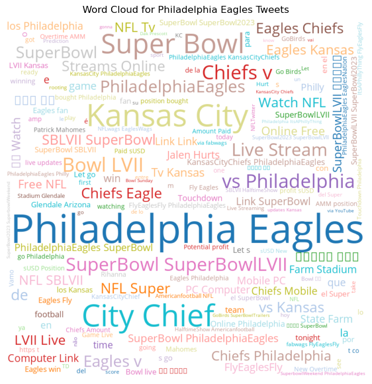

```python
import pandas as pd
from wordcloud import WordCloud
import matplotlib.pyplot as plt
from nltk.corpus import stopwords
import nltk
import re

# downloading the stopwords resource
#nltk.download('stopwords')

# removing stop words and URLs
stop_words = set(stopwords.words("english"))
df["content"] = df["content"].apply(lambda x: " ".join([word for word in x.split() if word not in stop_words and not re.match(r'http\S+', word)]))

# extracting text from "content" column and join into a single string
text = " ".join(df["content"])

# generating word cloud
wordcloud = WordCloud(width=800, height=800, background_color="white", font_path="OpenSans-Regular.ttf", max_font_size=150, min_font_size=10, colormap="tab20").generate(text)


plt.figure(figsize=(8,8))
plt.imshow(wordcloud, interpolation="bilinear")
plt.axis("off")
plt.title("Word Cloud for Philadelphia Eagles Tweets")
plt.show()
```

#### Sentiment analisys of 'eaglesdb' tweets

Sentiment analysis is a machine learning technique used to identify and extract subjective information from text data, such as opinions, attitudes, and emotions. The goal of the sentiment analysis is to determine the polarity of text data, which can be positive, negative, or neutral. To accomplish this, first the model must be trained to identify positive, negative, and neutral words in order to properly classify them.

For the Super Bowl 2023 tweeter analysis, the TextBlob python library was loaded and used as the polarity baseline. The sentiment analysis results from the “Philadelphia Eagles” tweets, showed that the tweets were in heavily in favor of the eagles. The chart below confirms this as the frequency for positive polarity is much higher than the negative frequencies. The Eagles were positively portrayed in the collection of tweets collected. The line above zero represents positive polarity while below represents negative polarity.

```
The tweets are in favor of the Eagles.
```

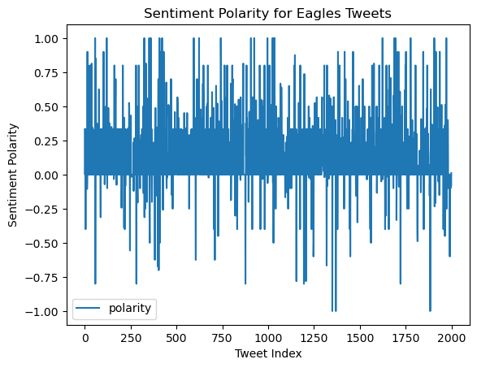

```python
import pymongo
import pandas as pd
import matplotlib.pyplot as plt
from textblob import TextBlob

# set up MongoDB client and database connection
client = pymongo.MongoClient("mongodb://localhost:27017/")
db = client["eaglesdb"]

# accessing the "eagles" collection
eaglescoll_v2 = db["eaglesdb"]

# creating a list of sentiment polarity and subjectivity values for all tweets
polarity_list = []
subjectivity_list = []
for tweet in eaglescoll.find():
    text = tweet["content"]
    blob = TextBlob(text)
    sentiment = blob.sentiment
    polarity = sentiment.polarity
    subjectivity = sentiment.subjectivity
    polarity_list.append(polarity)
    subjectivity_list.append(subjectivity)

# calculating overall sentiment polarity and subjectivity
total_polarity = sum(polarity_list)
total_subjectivity = sum(subjectivity_list)
num_tweets = len(polarity_list)

# calculating average sentiment polarity and subjectivity
if num_tweets > 0:
    avg_polarity = total_polarity / num_tweets
    avg_subjectivity = total_subjectivity / num_tweets
    if avg_polarity > 0:
        print("The tweets are in favor of the Eagles.")
    elif avg_polarity < 0:
        print("The tweets are in favor of Kansas City.")
    else:
        print("The tweets are neutral.")
else:
    print("No tweets found in the 'eagles' collection.")

# creating a pandas dataframe
data = {"polarity": polarity_list, "subjectivity": subjectivity_list}
df = pd.DataFrame(data)

# creating a line chart of sentiment polarity over time
df.plot(kind="line", y="polarity")
plt.title("Sentiment Polarity for Eagles Tweets")
plt.xlabel("Tweet Index")
plt.ylabel("Sentiment Polarity")
plt.show()
```

#### Repeating the process for the second query: "super bowl 2023"

```python
# This program scrapes 2000 tweets from the Tweeter database using snscrape platform.
# The tweets are publically available and start on 02-12-2023 and end on 02-13-2023
# to ensure the tweets are from the day of the game
# A new mongoDB database was created: "superdb" and the tweets were saved in the collection superdbcoll.

import pymongo
import snscrape.modules.twitter as sntwitter

# setting up MongoDB client and database connection
client = pymongo.MongoClient("mongodb://localhost:27017/")
db = client["superdb"]

# defining search query and number of tweets to scrape
query = '(super bowl 2023) since:2023-02-12 until:2023-02-13'
num_tweets = 2000

# scrape tweets and store in MongoDB collection
tweets_list = []
for i, tweet in enumerate(sntwitter.TwitterSearchScraper(query=query).get_items()):
    if i >= num_tweets:
        break
    tweet_dict = {
        "date": tweet.date,
        "id": tweet.id,
        "content": tweet.content,
        "username": tweet.user.username
    }
    tweets_list.append(tweet_dict)

superdbcoll = db["superdb"]
superdbcoll.insert_many(tweets_list)
```

```
<pymongo.results.InsertManyResult at 0x2f519be5240>
```

```python
# find the first 10 documents in the collection
docs = superdbcoll.find().limit(5)

# print each document
for document in docs:
    print(document)
```

```
{'_id': ObjectId('6404b7698748aafacd1bf6a7'), 'date': datetime.datetime(2023, 2, 12, 23, 59, 59), 'id': 1624921290053152772, 'content': "I just earned the 'Stadium Beers (2023)' badge on @untappd! https://t.co/j6BFdRNCpU #superbowl #football #lager", 'username': 'mildandlazyguy'}
{'_id': ObjectId('6404b7698748aafacd1bf6a8'), 'date': datetime.datetime(2023, 2, 12, 23, 59, 53), 'id': 1624921264874827785, 'content': 'Super Bowl 2023 ... und wem drückt ihr in diesem Jahr die Daumen? 😉\n\n#valeriafischer6\n#superbowl\n#superbowl2023 @ Erlangen, Germany https://t.co/wmZbFqKQu7', '…
{'_id': ObjectId('6404b7698748aafacd1bf6a9'), 'date': datetime.datetime(2023, 2, 12, 23, 59, 53), 'id': 1624921263369240576, 'content': '2023 Jennifer Lopez is winning. Jennifer Coolidge TikTok &amp; Dunkin Donut #SuperBowl ad. Love chill funny JLo', 'username': 'AmoreNora'}
{'_id': ObjectId('6404b7698748aafacd1bf6aa'), 'date': datetime.datetime(2023, 2, 12, 23, 59, 52), 'id': 1624921261447970816, 'content': '🔴 Super Bowl 2023 EN VIVO Kansas City Chiefs vs. Philadelphia Eagles: \n\nAsí entró Hurts a las diagonales😵\u200d💫\U0001faf6🏾 \n\nhttps://t.co/JvVOnMqKpa \n\n#LosM…
{'_id': ObjectId('6404b7698748aafacd1bf6ab'), 'date': datetime.datetime(2023, 2, 12, 23, 59, 52), 'id': 1624921260428824578, 'content': '📢 utilidade pública: O Super Bowl 2023 ta sendo transmitido ao vivo pela ESPN, Rede TV, Star+ e NFL Game Pass, veeeem Rihanna.', 'username': 'caliaricentral'}
```

```python
# showing existing databases to confirm new database superdb crated
client.list_database_names()
```

```
['admin',
 'bball2022',
 'config',
 'e_winnerdb',
 'eagles_winnerdb',
 'eaglesdb',
 'eaglesdb_v2',
 'fbusers',
 'local',
 'mydatabase',
 'new_database',
 'peopledb',
 'superbowl',
 'superbowl_winners',
 'superdb',
 'usgs',
 'usgsDB']
```

```python
import pandas as pd
# retrieving all documents in the superdbcoll and convert to list of dictionaries
documents = list(superdbcoll.find())

# converting list of dictionaries to Pandas DataFrame
df2 = pd.DataFrame(documents)

df2 = df[['date', 'id', 'content', 'username']]

# print the first 10 rows of the DataFrame
print(df2.head(3))

#df2.to_csv("superbowl.csv")
```

[output not shown]

```python
# Total number of tweets collected after the start of the game
# The game started at 6:30 pm Easter Time
len(df2[df2['date'] >= "2023-02-12 18:30:00"])
```

```
2000
```

#### Generating a word cloud and sentiment analysis for "super bowl 2023"

[figure not shown]

```python
import pandas as pd
from wordcloud import WordCloud
import matplotlib.pyplot as plt
from nltk.corpus import stopwords
import nltk
import re

# download the stopwords resource
#nltk.download('stopwords')

# removing stop words and URLs
stop_words = set(stopwords.words("english"))
df2["content"] = df2["content"].apply(lambda x: " ".join([word for word in x.split() if word not in stop_words and not re.match(r'http\S+', word)]))

# extracting text from "content" column and join into a single string
text = " ".join(df2["content"])

# generating word cloud with custom font, adjusted frequency, and custom colormap
wordcloud = WordCloud(width=800, height=800, background_color="white", font_path="OpenSans-Regular.ttf", max_font_size=150, min_font_size=10, colormap="tab20").generate(text)


plt.figure(figsize=(8,8))
plt.imshow(wordcloud, interpolation="bilinear")
plt.axis("off")
plt.title("Word Cloud for Super Bowl 2023 Tweets")
plt.show()
```

From the 2000 tweets sample collected using the query words “super bowl 2023”, the sentiment analysis produced a positive polarity regarding the Super Bowl 2023 event. It is important to highlight that the query is asking for tweets that have the words “super bowl 2023”, and not necessarily who will be the winners. So, it does not work in this scenario as a predictor for who the winner would be. Perhaps a sentiment analysis could be used in this context only after isolating the specific tweets that declared who the winners would be. This would require more in-depth Natural Language processing methods, which are beyond the scope of this analysis. Nevertheless, the chart below shows that the positive polarity towards the event far exceed the negative polarity.

```
The tweets are positive towards Super Bowl 2023.
```

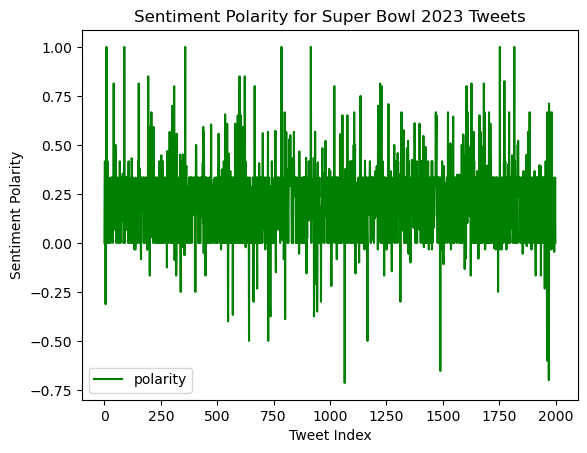

```python
import pymongo
import pandas as pd
import matplotlib.pyplot as plt
from textblob import TextBlob

# setting up MongoDB client and database connection
client = pymongo.MongoClient("mongodb://localhost:27017/")
db = client["superdb"]

# accessing the "superbowl_winners" collection
superdbcoll = db["superdb"]

# creating a list of sentiment polarity and subjectivity values for all tweets
polarity_list = []
subjectivity_list = []
for tweet in superdbcoll.find():
    text = tweet["content"]
    blob = TextBlob(text)
    sentiment = blob.sentiment
    polarity = sentiment.polarity
    subjectivity = sentiment.subjectivity
    polarity_list.append(polarity)
    subjectivity_list.append(subjectivity)

# calculating overall sentiment polarity and subjectivity
total_polarity = sum(polarity_list)
total_subjectivity = sum(subjectivity_list)
num_tweets = len(polarity_list)

# calculating average sentiment polarity and subjectivity
if num_tweets > 0:
    avg_polarity = total_polarity / num_tweets
    avg_subjectivity = total_subjectivity / num_tweets
    if avg_polarity > 0:
        print("The tweets are positive towards Super Bowl 2023.")
    elif avg_polarity < 0:
        print("The tweets are Negative towards Super Bowl 2023.")
    else:
        print("The tweets are neutral.")
else:
    print("No tweets found in the 'superbowl 2023' collection.")

# creating a pandas dataframe with sentiment polarity and subjectivity values
data = {"polarity": polarity_list, "subjectivity": subjectivity_list}
df2 = pd.DataFrame(data)

# creating a line chart of sentiment polarity over time
df2.plot(kind="line", y="polarity", color = "green")
plt.title("Sentiment Polarity for Super Bowl 2023 Tweets")
plt.xlabel("Tweet Index")
plt.ylabel("Sentiment Polarity")
plt.show()
```

#### 2 – Is the choice of query words relevant for the accuracy of results?

Yes, the choice of query words played a very important role when collecting samples from the tweeter database. By selecting “Philadelphia Eagles” the results of the sentiment analysis and word cloud were biased towards the “Philadelphia Eagles”. If the query had words like “Kansas City”, we would undoubtedly have seen similar results to what was seen with the “Philadelphia Eagles” query, but with Kansas City as the favorites instead.

When querying using SNS scrape, the SNS will search for tweets that contains all the words in the query in any order. This means that the query will return tweets that mention super, bowl, 2023, Philadelphia, and Eagles anywhere in the tweet, including the content, hashtags, and usernames. Since Kansas City was not part of the query, the results were automatically biased towards Philadelphia Eagles.

### Conclusion

The word cloud and sentiment analysis are great tools for quickly assessing the overall sentiment of a large text data sets. As far as predicting who the winner would be, sentiment analysis would have been better suited if the tweets were further filtered to have user inputs that specifically declared their support for a team. Tweeter offers several tears of data that contain user inputs that could have been more appropriate for this analysis but can only be accessed through memberships, and therefore were not used in this study.